# main

```python
import numpy as np
import pandas as pd
from matplotlib import pyplot as plt
from sklearn.decomposition import PCA
```

## Exercise 1

```python
# item 1

N_SAMPLES = 100

CLASS_0 = ( (2, 3), (0.8, 2.5))
CLASS_1 = ( (5, 6), (1.2, 1.9))
CLASS_2 = ( (8, 1), (0.9, 0.9))
CLASS_3 = ((15, 4), (0.5, 2.0))

def generate_data(CLASS_data, n_samples) -> np.ndarray[np.ndarray, np.ndarray]:
    dim_0 = np.random.normal(loc=CLASS_data[0][0], scale=CLASS_data[1][0], size=n_samples)
    dim_1 = np.random.normal(loc=CLASS_data[0][1], scale=CLASS_data[1][1], size=n_samples)
    return np.array(list(zip(dim_0, dim_1)))

class_0_data = generate_data(CLASS_0, N_SAMPLES)
class_1_data = generate_data(CLASS_1, N_SAMPLES)
class_2_data = generate_data(CLASS_2, N_SAMPLES)
class_3_data = generate_data(CLASS_3, N_SAMPLES)
```

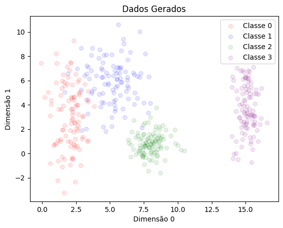

```python
# item 2

plt.scatter(class_0_data[:,0], class_0_data[:,1], color='red', label='Classe 0', alpha=0.1)
plt.scatter(class_1_data[:,0], class_1_data[:,1], color='blue', label='Classe 1', alpha=0.1)
plt.scatter(class_2_data[:,0], class_2_data[:,1], color='green', label='Classe 2', alpha=0.1)
plt.scatter(class_3_data[:,0], class_3_data[:,1], color='purple', label='Classe 3', alpha=0.1)
plt.xlabel('Dimensão 0')
plt.ylabel('Dimensão 1')
plt.title('Dados Gerados')
plt.legend()
plt.show()
```

### Item 3

**a.** Observing the scatter plot, a few things stand out.

- Class 3 is very easily distinguishable from the others, since its values of X (dim 0) are fairly distant from all the others'.
- Class 2 is much closer to the others, but there is pretty much no overlap with class 0 and a possibly a little with class 1.
- Classes 0 and 1 have considerable visual overlap.

**b.** One single linear boundary, absolutely not. Three linear boundaries, yes.

**c.** Below

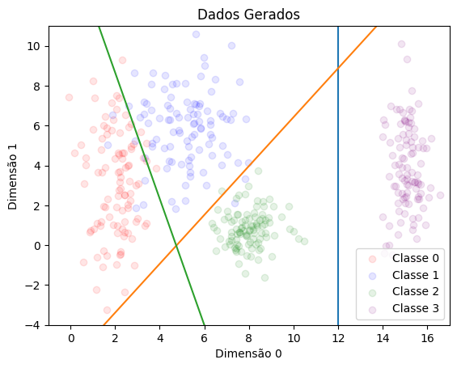

```python
plt.scatter(class_0_data[:,0], class_0_data[:,1], color='red', label='Classe 0', alpha=0.1)
plt.scatter(class_1_data[:,0], class_1_data[:,1], color='blue', label='Classe 1', alpha=0.1)
plt.scatter(class_2_data[:,0], class_2_data[:,1], color='green', label='Classe 2', alpha=0.1)
plt.scatter(class_3_data[:,0], class_3_data[:,1], color='purple', label='Classe 3', alpha=0.1)
plt.xlabel('Dimensão 0')
plt.ylabel('Dimensão 1')
plt.title('Dados Gerados')
plt.legend()
plt.plot([12,12], [-5, 15])
plt.plot([1.5,17], [-4,15])
plt.plot([6,0], [-4,15])
plt.xlim(-1, 17)
plt.ylim(-4, 11)
plt.show()
```

## Exercise 2

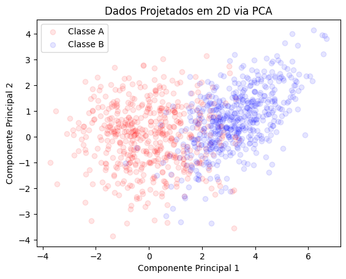

```python
# item 1

class_A_mean = np.zeros(5)
class_B_mean = np.array([1.5] * 5)

class_A_cov = np.array([
    [1,0.8,0.1,0,0],
    [0.8,1,0.3,0,0],
    [0.1,0.3,1,0.5,0],
    [0,0,0.5,1,0.2],
    [0,0,0,0.2,1]
])

class_B_cov = np.array([
    [1,-0.7,0.2,0,0],
    [-0.7,1.5,0.4,0,0],
    [0.2,0.4,1.5,0.6,0],
    [0,0,0.6,1.5,0.3],
    [0,0,0,0.3,1.5]
])

class_A_data = np.random.multivariate_normal(mean=class_A_mean, cov=class_A_cov, size=500)
class_B_data = np.random.multivariate_normal(mean=class_B_mean, cov=class_B_cov, size=500)

pca = PCA(n_components=2)
class_A_data_2d = pca.fit_transform(class_A_data)
class_B_data_2d = pca.transform(class_B_data)

plt.scatter(class_A_data_2d[:,0], class_A_data_2d[:,1], color='red', label='Classe A', alpha=0.1)
plt.scatter(class_B_data_2d[:,0], class_B_data_2d[:,1], color='blue', label='Classe B', alpha=0.1)
plt.xlabel('Componente Principal 1')
plt.ylabel('Componente Principal 2')
plt.title('Dados Projetados em 2D via PCA')
plt.legend()
plt.show()
```

### Item 3

**a.** There seems to be a fair amount of overlap between the two classes.

**b.** Since there is a bit of overlap between the classes when reducing them to 2D, a linear separation of the two seems impossible.

## Exercise 3

## Item 1

Data in `./data`

## Item 2

| Column Name | Data Type | Train Missing | Total Missing | Description |
| --- | --- | --- | --- | --- |
| `PassengerId` | CAT | 0.00% | 0.00% | Unique identifier for each passenger. Follows format `gggg_pp` where `gggg` is the group of the passenger and `pp` is the number of the passenger within that group. |
| `HomePlanet` | CAT | 2.31% | 2.22% | Planet where the passenger departed from. |
| `CryoSleep` | CAT | 2.50% | 2.39% | If the passenger opted to be in cryo sleep for the duration of the journey. They are confined to their cabins. |
| `Cabin` | CAT | 2.29% | 2.31% | Cabin number where the passenger is staying, Follows format `deck/num/side`, `side` can be either `P` or `S` for Port and Starboard. |
| `Destination` | CAT | 2.09% | 2.11% | Planet where the passenger will debark. |
| `Age` | NUM | 2.06% | 2.08% | Age of the passenger. |
| `VIP` | CAT | 2.34% | 2.28% | Paid for VIP services or not. |
| `RoomService` | NUM | 2.08% | 2.03% | Amount spent in room service. |
| `FoodCourt` | NUM | 2.11% | 2.23% | Amount spent at the food court. |
| `ShoppingMall` | NUM | 2.39% | 2.36% | Amount spent at the shopping mall. |
| `Spa` | NUM | 2.11% | 2.19% | Amount spent at the spa. |
| `VRDeck` | NUM | 2.16% | 2.07% | Amount spent at the VR Deck. |
| `Name` | CAT | 2.30% | 2.27% | First and last name of the passenger. |
| `Transported` | CAT | 0.00% | 32.98% | Whether or not the passenger got transported into another dimension after the ship hit the spacetime anomaly. This is the target column. |

```python
df_train = pd.read_csv('../data/train.csv')
df_test = pd.read_csv('../data/test.csv')
df_train = df_train.drop(columns=['PassengerId', 'Name'])

missing_values = df_train.isnull().sum() / len(df_train)
missing_values
```

```
HomePlanet      0.023122
CryoSleep       0.024963
Cabin           0.022892
Destination     0.020936
Age             0.020591
VIP             0.023352
RoomService     0.020821
FoodCourt       0.021051
ShoppingMall    0.023927
Spa             0.021051
VRDeck          0.021627
Transported     0.000000
dtype: float64
```

### Item 3

- Missing Values:
  - Categorical: fill out the values randomly but keeping the same proportions of the values not missing (except `Name` and `Cabin`)
  - Numerical: fill out with the average
  - Cabin: will be split into `CabinSide` and `CabinDeck` and then those two will be filled out similarly

```python
df_train["CabinSide"] = df_train["Cabin"].str[-1]
df_train["CabinDeck"] = df_train["Cabin"].str.split('/').str[0]
df_train = df_train.drop(columns=['Cabin'])
```

```python
categorical_columns = ['HomePlanet', 'CryoSleep', 'Destination', 'VIP', 'CabinSide', 'CabinDeck']

for column in categorical_columns:
    print(f"Proportions for {column}:")
    print(df_train[column].value_counts(normalize=True))
    print()
```

```
Proportions for HomePlanet:
HomePlanet
Earth     0.541922
Europa    0.250942
Mars      0.207136
Name: proportion, dtype: float64

Proportions for CryoSleep:
CryoSleep
False    0.641694
True     0.358306
Name: proportion, dtype: float64

Proportions for Destination:
Destination
TRAPPIST-1e      0.694983
55 Cancri e      0.211491
PSO J318.5-22    0.093526
Name: proportion, dtype: float64

Proportions for VIP:
VIP
False    0.976561
True     0.023439
Name: proportion, dtype: float64

Proportions for CabinSide:
CabinSide
S    0.504827
P    0.495173
Name: proportion, dtype: float64

Proportions for CabinDeck:
CabinDeck
F    0.328938
G    0.301271
E    0.103132
B    0.091712
C    0.087944
D    0.056275
A    0.030139
T    0.000589
Name: proportion, dtype: float64
```

```python
for column in categorical_columns:
    proportions = df_train[column].value_counts(normalize=True, dropna=True)
    missing_count = df_train[column].isnull().sum()
    df_train.loc[df_train[column].isnull(), column] = np.random.choice(
        proportions.index, size=missing_count, p=proportions.values
    )
```

```python
for column in categorical_columns:
    print(f"Proportions for {column}:")
    print(df_train[column].value_counts(normalize=True))
    print()
```

```
Proportions for HomePlanet:
HomePlanet
Earth     0.542736
Europa    0.250776
Mars      0.206488
Name: proportion, dtype: float64

Proportions for CryoSleep:
CryoSleep
False    0.641896
True     0.358104
Name: proportion, dtype: float64

Proportions for Destination:
Destination
TRAPPIST-1e      0.695502
55 Cancri e      0.210744
PSO J318.5-22    0.093754
Name: proportion, dtype: float64

Proportions for VIP:
VIP
False    0.976763
True     0.023237
Name: proportion, dtype: float64

Proportions for CabinSide:
CabinSide
S    0.505234
P    0.494766
Name: proportion, dtype: float64

Proportions for CabinDeck:
CabinDeck
F    0.330381
G    0.300012
E    0.102841
B    0.092028
C    0.087772
D    0.056252
A    0.030139
T    0.000575
Name: proportion, dtype: float64
```

```python
numerical_columns = ['Age', 'RoomService', 'FoodCourt', 'ShoppingMall', 'Spa', 'VRDeck']

for column in numerical_columns:
    mean_value = df_train[column].mean()
    df_train[column].fillna(mean_value, inplace=True)
```

```python
missing_values = df_train.isnull().sum() / len(df_train)
missing_values
```

```
HomePlanet      0.0
CryoSleep       0.0
Destination     0.0
Age             0.0
VIP             0.0
RoomService     0.0
FoodCourt       0.0
ShoppingMall    0.0
Spa             0.0
VRDeck          0.0
Transported     0.0
CabinSide       0.0
CabinDeck       0.0
dtype: float64
```

```python
# one-hot encode categorical variables with more than two categories
one_hot_encode_columns = ['HomePlanet', 'Destination', 'CabinDeck']
df_train = pd.get_dummies(df_train, columns=one_hot_encode_columns, drop_first=True)
print(df_train.head())
```

```
  CryoSleep   Age    VIP  RoomService  FoodCourt  ShoppingMall     Spa  \
0     False  39.0  False          0.0        0.0           0.0     0.0
1     False  24.0  False        109.0        9.0          25.0   549.0
2     False  58.0   True         43.0     3576.0           0.0  6715.0
3     False  33.0  False          0.0     1283.0         371.0  3329.0
4     False  16.0  False        303.0       70.0         151.0   565.0

   VRDeck  Transported CabinSide  ...  HomePlanet_Mars  \
0     0.0        False         P  ...            False
1    44.0         True         S  ...            False
2    49.0        False         S  ...            False
3   193.0        False         S  ...            False
4     2.0         True         S  ...            False

   Destination_PSO J318.5-22  Destination_TRAPPIST-1e  CabinDeck_B  \
```

[output cut: 21 more lines]

```python
# calculate z-scores for numerical columns
for column in numerical_columns:
    df_train[column] = (df_train[column] - df_train[column].mean()) / df_train[column].std()
```

```python
# change true and false to 1 and 0
df_train['CryoSleep'] = df_train['CryoSleep'].astype(int)
df_train['VIP'] = df_train['VIP'].astype(int)
df_train['CabinSide'] = df_train['CabinSide'].map({'P': 1, 'S': 0})
```

```python
df_train
```

|  | CryoSleep | Age | VIP | RoomService | FoodCourt | ShoppingMall | Spa | VRDeck | Transported | CabinSide | ... | HomePlanet_Mars | Destination_PSO J318.5-22 | Destination_TRAPPIST-1e | CabinDeck_B | CabinDeck_C | CabinDeck_D | CabinDeck_E | CabinDeck_F | CabinDeck_G | CabinDeck_T |
| --- | --- | --- | --- | --- | --- | --- | --- | --- | --- | --- | --- | --- | --- | --- | --- | --- | --- | --- | --- | --- | --- |
| 0 | 0 | 0.709396 | 0 | -0.340570 | -0.287298 | -0.290800 | -0.276648 | -0.269007 | False | 1 | ... | False | False | True | True | False | False | False | False | False | False |
| 1 | 0 | -0.336698 | 0 | -0.175354 | -0.281653 | -0.248954 | 0.211493 | -0.230181 | True | 0 | ... | False | False | True | False | False | False | False | True | False | False |
| 2 | 0 | 2.034449 | 1 | -0.275393 | 1.955503 | -0.290800 | 5.693962 | -0.225769 | False | 0 | ... | False | False | True | False | False | False | False | False | False | False |
| 3 | 0 | 0.290958 | 0 | -0.340570 | 0.517376 | 0.330206 | 2.683316 | -0.098702 | False | 0 | ... | False | False | True | False | False | False | False | False | False | False |
| 4 | 0 | -0.894615 | 0 | 0.118702 | -0.243395 | -0.038046 | 0.225719 | -0.267242 | True | 0 | ... | False | False | True | False | False | False | False | True | False | False |
| ... | ... | ... | ... | ... | ... | ... | ... | ... | ... | ... | ... | ... | ... | ... | ... | ... | ... | ... | ... | ... | ... |
| 8688 | 0 | 0.848875 | 1 | -0.340570 | 3.989453 | -0.290800 | 1.184218 | -0.203709 | False | 1 | ... | False | False | False | False | False | False | False | False | False | False |
| 8689 | 1 | -0.755136 | 0 | -0.340570 | -0.287298 | -0.290800 | -0.276648 | -0.269007 | False | 0 | ... | False | True | False | False | False | False | False | False | True | False |
| 8690 | 0 | -0.197219 | 0 | -0.340570 | -0.287298 | 2.842687 | -0.275758 | -0.269007 | True | 0 | ... | False | False | True | False | False | False | False | False | True | False |
| 8691 | 0 | 0.221219 | 0 | -0.340570 | 0.370616 | -0.290800 | 0.037221 | 2.585592 | False | 0 | ... | False | False | False | False | False | False | True | False | False | False |
| 8692 | 0 | 1.058094 | 0 | -0.149586 | 2.652929 | -0.290800 | -0.276648 | -0.258418 | True | 0 | ... | False | False | True | False | False | False | True | False | False | False |

8693 rows × 21 columns